# project : healthcare-dataset-stroke-data

# A-Categorical Data

## Percentages :

### 1-Stroke

```
0    4861
1     249
Name: stroke, dtype: int64
```

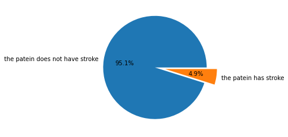

```python
len_stroke=pd.value_counts(df['stroke'])
print(len_stroke)
plt.pie(len_stroke,labels=('the patein does not have stroke','the patein has stroke'),explode=(0.1,0.1), autopct='%1.1f%%');
```

### We found in these data :

- the number of the patein does not have stroke 4861 and their percentage 95.1 % >
- the number of the patein has stroke 249 and their percentage 4.9 %

### 2-Hypertension

```
0    4612
1     498
Name: hypertension, dtype: int64
```

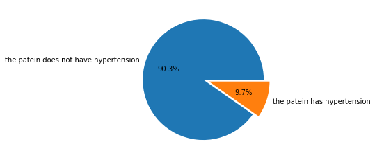

```python
len_hyp=pd.value_counts(df['hypertension'])
print(len_hyp)
plt.pie(len_hyp,labels=('the patein does not have hypertension','the patein has hypertension'),explode=(0.,0.1), autopct='%1.1f%%');
```

### We found in these data :

- the number of the patein does not have hypertension 4612 and their percentage 90.3 % >
- the number of the patein has hypertension 498 and their percentage 9.7 %¶

### 3-heart_disease

```
0    4834
1     276
Name: heart_disease, dtype: int64
```

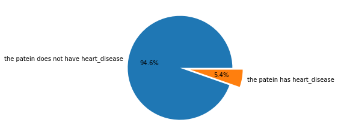

```python
len_hd=pd.value_counts(df['heart_disease'])
print(len_hd)
plt.pie(len_hd,labels=('the patein does not have heart_disease','the patein has heart_disease'),explode=(0.1,0.1), autopct='%1.1f%%');
```

### We found in these data :

- the number of the patein does not have heart disease 4834 and their percentage 94.6 % > *and that the number of the patein has heart disease 276 and their percentage 5.4 %

### 4-Gender

```
Female    2994
Male      2115
Other        1
Name: gender, dtype: int64
```

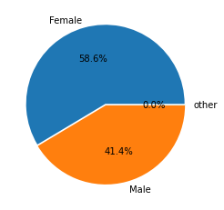

```python
len_g=pd.value_counts(df['gender'])
print(len_g)
plt.pie(len_g,labels=('Female','Male','other'),explode=(0.01,0.01,0.01), autopct='%1.1f%%');
```

### We found in these data :

- the number of Males 2115 and their percentage 41.4 % >
- the number of Females 2994 and their percentage 58.6 %

### 5-Married

```
Yes    3353
No     1757
Name: ever_married, dtype: int64
```

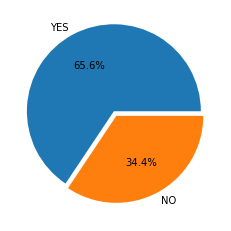

```python
len_m=pd.value_counts(df['ever_married'])
print(len_m)
plt.pie(len_m,labels=('YES','NO'),explode=(0.05,0.01), autopct='%1.1f%%');
```

### We found in these data :

- the number of married couples 3353 and their percentage 65.6 % > *and that the number of unmarried 1757 and their percentage 34.4 %

### 6-Smoking

```
never smoked       1892
Unknown            1544
formerly smoked     885
smokes              789
Name: smoking_status, dtype: int64
```

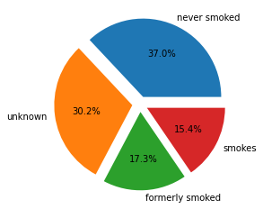

```python
len_s=pd.value_counts(df['smoking_status'])
print(len_s)
plt.pie(len_s,labels=('never smoked','unknown','formerly smoked','smokes'),explode=(0.1,0.1,0.1,0.1), autopct='%1.1f%%');
```

### 7-Residence type

```
Urban    2596
Rural    2514
Name: Residence_type, dtype: int64
```

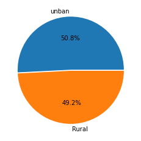

```python
len_rt=pd.value_counts(df['Residence_type'])
print(len_rt)
plt.pie(len_rt,labels=('unban','Rural'),explode=(0.01,0.01), autopct='%1.1f%%');
```

### 8- Work Type

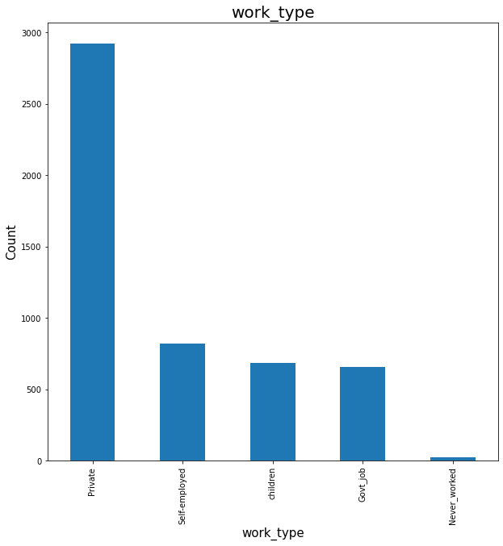

```python
plt.title('work_type', fontsize=20)
plt.xticks(fontsize=10)
plt.yticks(fontsize=10)
plt.xlabel('work_type',fontsize=15)
plt.ylabel('Count', fontsize=15)
pd.value_counts(df['work_type']).plot(kind='bar', figsize=(10,10));
```

# B-Continous Data

## - BoxPlot

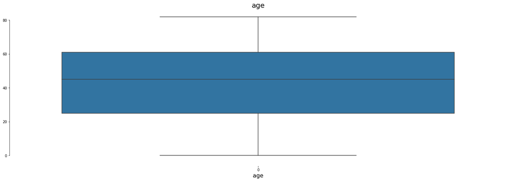

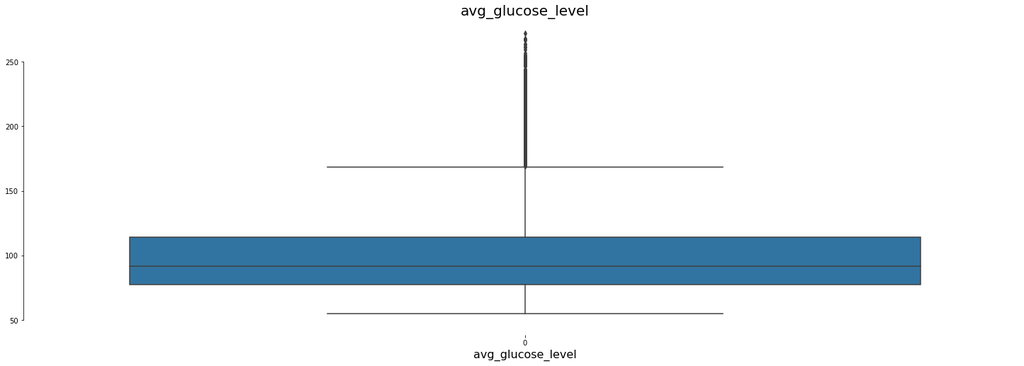

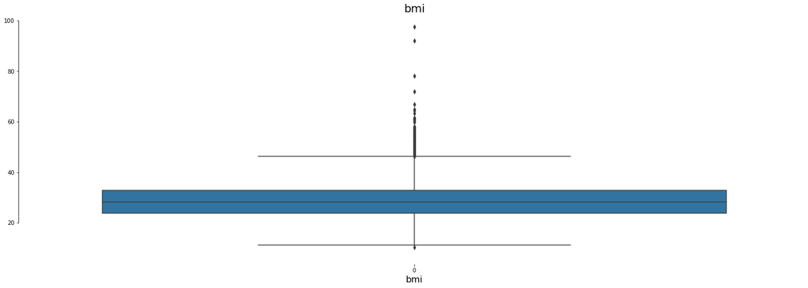

```python
cnt = 0
max_in_row = 1
for x in cont_cols:
    data = df[x]
    plt.figure(cnt//max_in_row, figsize=(25,8))
    plt.subplot(1, max_in_row, (cnt)%max_in_row + 1)
    plt.title(x, fontsize=20)
    plt.xticks(fontsize=16)
    plt.yticks(fontsize=16)
    plt.xlabel(x, fontsize=16)
    sns.boxplot(data = data);
    sns.despine(offset=10, trim=True);
    cnt += 1
```

# Discover Distributions :

# Distribution of continuous features

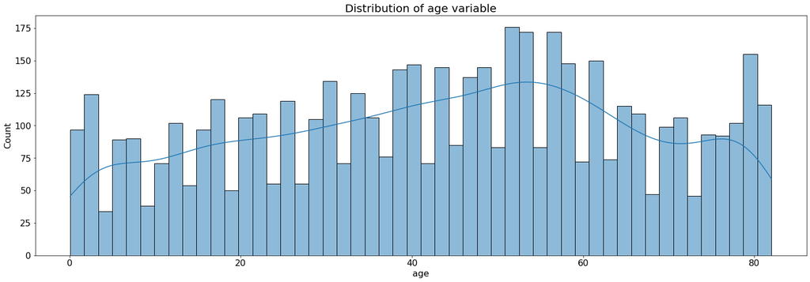

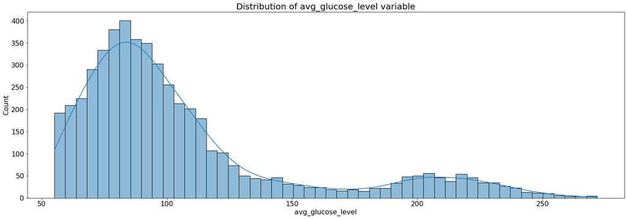

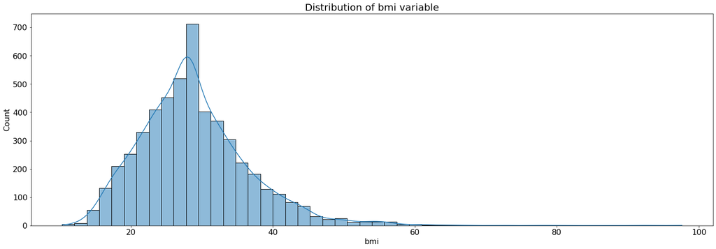

```python
cnt = 0
max_in_row = 1
for x in cont_cols:
    data = df[x]
    plt.figure(cnt//max_in_row, figsize=(25,8))
    plt.subplot(1, max_in_row, (cnt)%max_in_row + 1)
    plt.title(f'Distribution of {x} variable', fontsize=20)
    plt.xticks(fontsize=16)
    plt.yticks(fontsize=16)
    plt.xlabel(x, fontsize=16)
    plt.ylabel('Count', fontsize=16)
    sns.histplot(data, bins = 50, kde=50);
    cnt += 1
```

# Statistics continous columns

```python
df[continous_cols].describe().T
```

[output not shown]

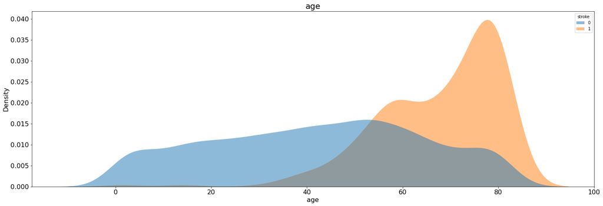

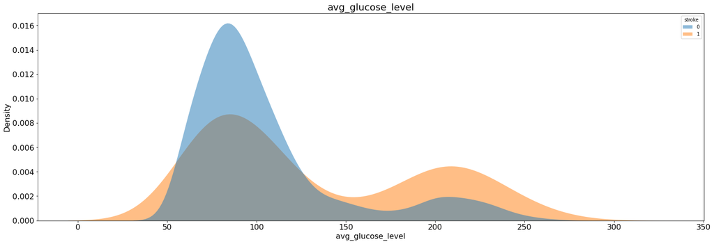

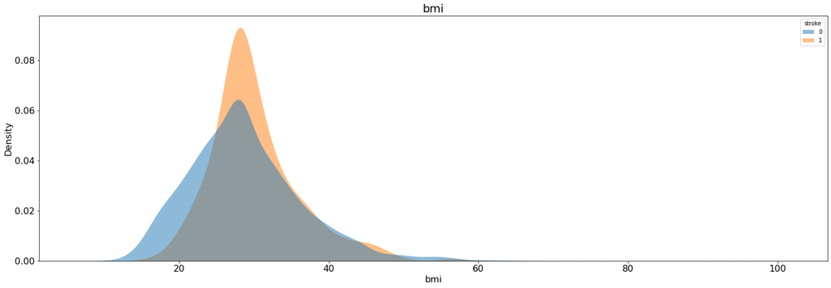

```python
cnt = 0
max_in_row = 1
for x in cont_cols:
    plt.figure(cnt//max_in_row, figsize=(25,8))
    plt.subplot(1, max_in_row, (cnt)%max_in_row + 1)
    plt.title(x, fontsize=20)
    plt.xticks(fontsize=16)
    plt.yticks(fontsize=16)
    plt.xlabel(x, fontsize=16)
    plt.ylabel('Density', fontsize=16)
    sns.kdeplot(data=df, x=x, hue="stroke", fill=True, common_norm=False, alpha=.5, linewidth=0);
    cnt += 1
```

```python
df
```

|  | gender | age | hypertension | heart_disease | ever_married | work_type | Residence_type | avg_glucose_level | bmi | smoking_status | stroke |
| --- | --- | --- | --- | --- | --- | --- | --- | --- | --- | --- | --- |
| 0 | Male | 67.0 | 0 | 1 | Yes | Private | Urban | 228.69 | 36.6 | formerly smoked | 1 |
| 1 | Female | 61.0 | 0 | 0 | Yes | Self-employed | Rural | 202.21 | 28.1 | never smoked | 1 |
| 2 | Male | 80.0 | 0 | 1 | Yes | Private | Rural | 105.92 | 32.5 | never smoked | 1 |
| 3 | Female | 49.0 | 0 | 0 | Yes | Private | Urban | 171.23 | 34.4 | smokes | 1 |
| 4 | Female | 79.0 | 1 | 0 | Yes | Self-employed | Rural | 174.12 | 24.0 | never smoked | 1 |
| ... | ... | ... | ... | ... | ... | ... | ... | ... | ... | ... | ... |
| 5105 | Female | 80.0 | 1 | 0 | Yes | Private | Urban | 83.75 | 28.1 | never smoked | 0 |
| 5106 | Female | 81.0 | 0 | 0 | Yes | Self-employed | Urban | 125.20 | 40.0 | never smoked | 0 |
| 5107 | Female | 35.0 | 0 | 0 | Yes | Self-employed | Rural | 82.99 | 30.6 | never smoked | 0 |
| 5108 | Male | 51.0 | 0 | 0 | Yes | Private | Rural | 166.29 | 25.6 | formerly smoked | 0 |
| 5109 | Female | 44.0 | 0 | 0 | Yes | Govt_job | Urban | 85.28 | 26.2 | Unknown | 0 |

5110 rows × 11 columns

# Correlation

```python
df.corr()
```

|  | age | hypertension | heart_disease | avg_glucose_level | bmi | stroke |
| --- | --- | --- | --- | --- | --- | --- |
| age | 1.000000 | 0.276398 | 0.263796 | 0.238171 | 0.324296 | 0.245257 |
| hypertension | 0.276398 | 1.000000 | 0.108306 | 0.174474 | 0.158293 | 0.127904 |
| heart_disease | 0.263796 | 0.108306 | 1.000000 | 0.161857 | 0.036916 | 0.134914 |
| avg_glucose_level | 0.238171 | 0.174474 | 0.161857 | 1.000000 | 0.166876 | 0.131945 |
| bmi | 0.324296 | 0.158293 | 0.036916 | 0.166876 | 1.000000 | 0.036110 |
| stroke | 0.245257 | 0.127904 | 0.134914 | 0.131945 | 0.036110 | 1.000000 |

# Correlation Matrix

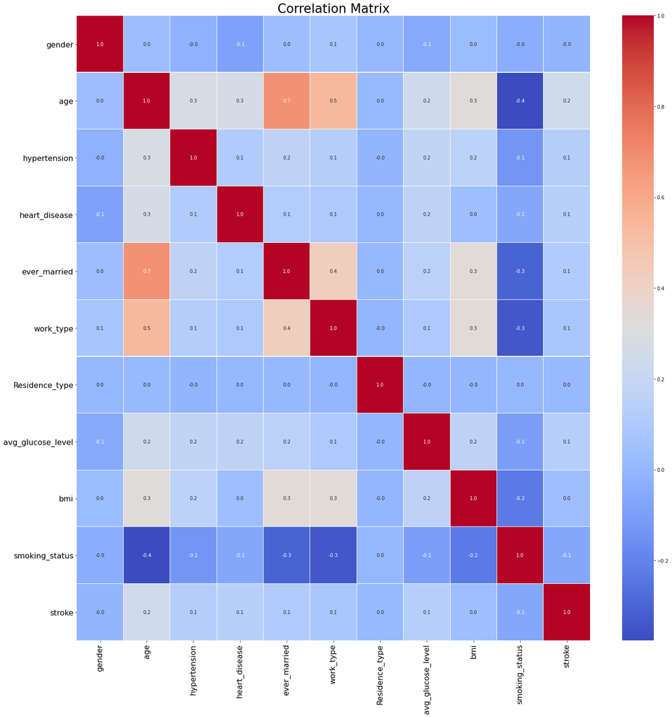

```python
plt.figure(figsize = (24, 24))
sns.heatmap(temp_df.corr(), cmap = "coolwarm", annot=True, fmt='.1f', linewidths=0.1);
plt.yticks(rotation=0, size=16)
plt.xticks(rotation=90,size=16)
plt.title('Correlation Matrix', size=26)
plt.show()
```

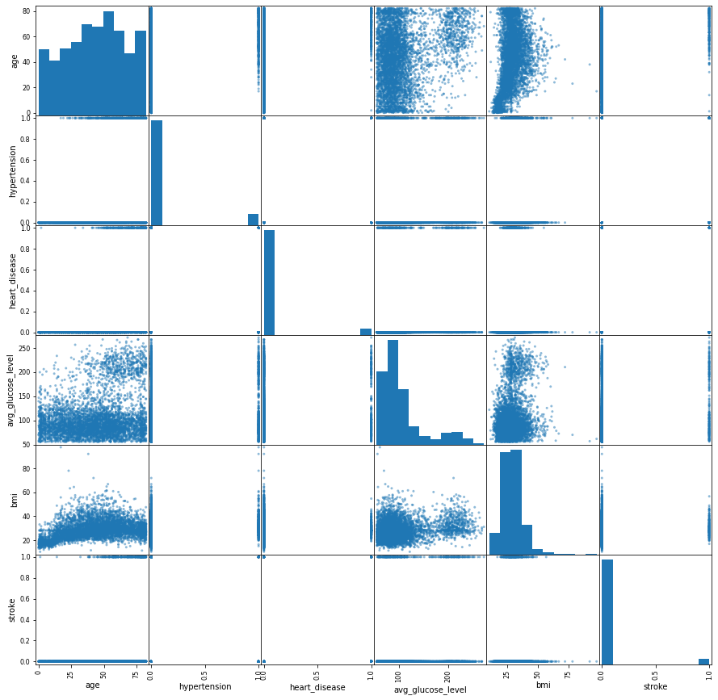

```python
pd.plotting.scatter_matrix(df,figsize=(15,15));
```

# Corrlation between Diseases :

```python
ill_cols=['hypertension', 'heart_disease','avg_glucose_level','stroke']
dt=df[ill_cols]
dt.corr()
```

|  | hypertension | heart_disease | avg_glucose_level | stroke |
| --- | --- | --- | --- | --- |
| hypertension | 1.000000 | 0.108306 | 0.174474 | 0.127904 |
| heart_disease | 0.108306 | 1.000000 | 0.161857 | 0.134914 |
| avg_glucose_level | 0.174474 | 0.161857 | 1.000000 | 0.131945 |
| stroke | 0.127904 | 0.134914 | 0.131945 | 1.000000 |

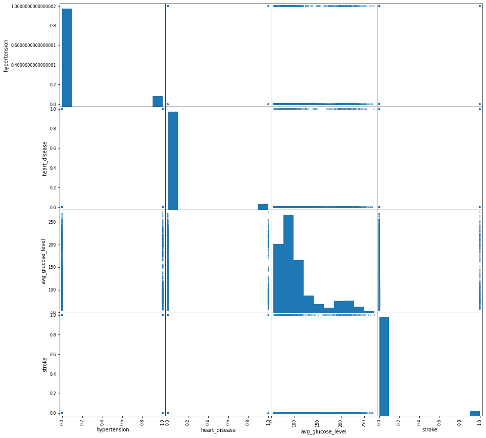

```python
pd.plotting.scatter_matrix(dt,figsize=(15,15));
```

# Classificationn od Diseeases by gender :

## 1-heart Disease

```python
a=df['heart_disease'].groupby(df['gender']).value_counts()
pd.DataFrame(a)
```

| gender | heart_disease | heart_disease |
| --- | --- | --- |
| Female | 0 | 2881 |
|  | 1 | 113 |
| Male | 0 | 1952 |
|  | 1 | 163 |
| Other | 0 | 1 |

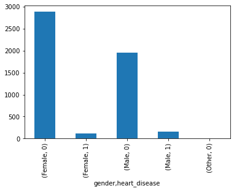

```python
a.plot(kind='bar');
```

## 2-Stroke

```python
s=df['stroke'].groupby(df['gender']).value_counts()
pd.DataFrame(s)
```

| gender | stroke | stroke |
| --- | --- | --- |
| Female | 0 | 2853 |
|  | 1 | 141 |
| Male | 0 | 2007 |
|  | 1 | 108 |
| Other | 0 | 1 |

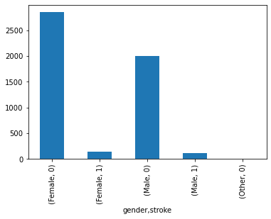

```python
s.plot(kind='bar');
```

## 3-hypertension

```python
h=df['hypertension'].groupby(df['gender']).value_counts()
pd.DataFrame(h)
```

| gender | hypertension | hypertension |
| --- | --- | --- |
| Female | 0 | 2718 |
|  | 1 | 276 |
| Male | 0 | 1893 |
|  | 1 | 222 |
| Other | 0 | 1 |

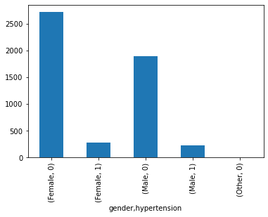

```python
h.plot(kind='bar');
```

# Classfiication of diseases by ever_married and gender:

## 1-Stroke

```python
sm=df['stroke'].groupby([df['gender'],df['ever_married']]).value_counts()
pd.DataFrame(sm)
```

| gender | ever_married | stroke | stroke |
| --- | --- | --- | --- |
| Female | No | 0 | 972 |
|  |  | 1 | 21 |
|  | Yes | 0 | 1881 |
|  |  | 1 | 120 |
| Male | No | 0 | 755 |
|  |  | 1 | 8 |
|  | Yes | 0 | 1252 |
|  |  | 1 | 100 |
| Other | No | 0 | 1 |

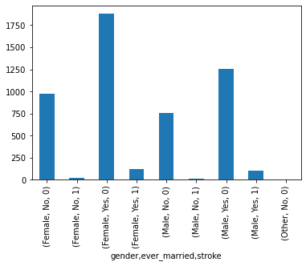

```python
sm.plot(kind='bar');
```

## 2-hypertension

```python
hgm=df['hypertension'].groupby([df['gender'],df['ever_married']]).value_counts()
pd.DataFrame(hgm)
```

| gender | ever_married | hypertension | hypertension |
| --- | --- | --- | --- |
| Female | No | 0 | 961 |
|  |  | 1 | 32 |
|  | Yes | 0 | 1757 |
|  |  | 1 | 244 |
| Male | No | 0 | 742 |
|  |  | 1 | 21 |
|  | Yes | 0 | 1151 |
|  |  | 1 | 201 |
| Other | No | 0 | 1 |

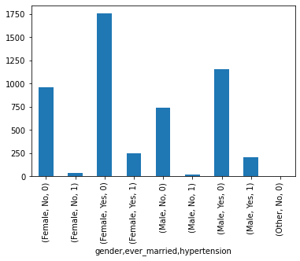

```python
hgm.plot.bar()
```

```python
sr=df['stroke'].groupby([df['Residence_type']]).value_counts()
pd.DataFrame(sr)
```

| Residence_type | stroke | stroke |
| --- | --- | --- |
| Rural | 0 | 2400 |
|  | 1 | 114 |
| Urban | 0 | 2461 |
|  | 1 | 135 |

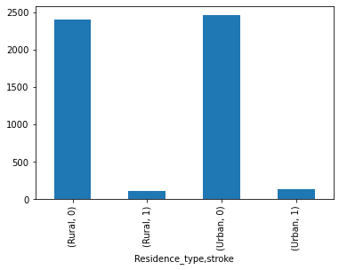

```python
sr.plot.bar();
```

# Classfiication stroke by Work type :

```python
sw=df['stroke'].groupby([df['work_type']]).value_counts()
pd.DataFrame(sw)
```

| work_type | stroke | stroke |
| --- | --- | --- |
| Govt_job | 0 | 624 |
|  | 1 | 33 |
| Never_worked | 0 | 22 |
| Private | 0 | 2776 |
|  | 1 | 149 |
| Self-employed | 0 | 754 |
|  | 1 | 65 |
| children | 0 | 685 |
|  | 1 | 2 |

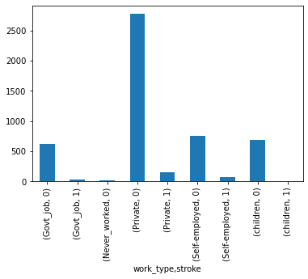

```python
sw.plot.bar();
```